# Unsupervised_Learning_Credit_Card_Segmentation_Project_Tiffany_Chan

HIERARCHICAL CLUSTERING USING COMPLETE LINKAGE METHOD WITH 3 CLUSTERS

```python
#We can use the complete linkage method and then fit it to the scaled data.
model = AgglomerativeClustering(n_clusters=3, affinity='euclidean',  linkage='complete')
model.fit(ccdatascaled2)
```

```
AgglomerativeClustering(linkage='complete', n_clusters=3)
```

```python
#We can also append these as labels to the unscaled and scaled data (3 clusters).
ccdata2['labels'] = model.labels_
ccdatascaled2['labels'] = model.labels_
```

```python
#This is made to answer the last question of the assignment
ccdata5 = ccdata2
print(ccdata5.head())
print("")
print("Frequency of all 3 labels")
print(ccdata5['labels'].value_counts())


ccdataclust5 = ccdata5.groupby(['labels'])
ccdataclust5.mean()
```

```
   Avg_Credit_Limit  Total_Credit_Cards  Total_visits_bank  \
0            100000                   2                  1
1             50000                   3                  0
2             50000                   7                  1
3             30000                   5                  1
4            100000                   6                  0

   Total_visits_online  Total_calls_made  labels
0                    1                 0       0
1                   10                 9       2
2                    3                 4       0
3                    1                 4       0
4                   12                 3       1

Frequency of all 3 labels
0    389
2    221
1     50
Name: labels, dtype: int64
```

| labels | Avg_Credit_Limit | Total_Credit_Cards | Total_visits_bank | Total_visits_online | Total_calls_made |
| --- | --- | --- | --- | --- | --- |
| 0 | 33629.820051 | 5.503856 | 3.478149 | 0.997429 | 2.015424 |
| 1 | 102660.000000 | 8.740000 | 0.600000 | 10.900000 | 1.080000 |
| 2 | 12149.321267 | 2.389140 | 0.918552 | 3.561086 | 6.909502 |

```
array([[<matplotlib.axes._subplots.AxesSubplot object at 0x000002AB3B329F40>,
      dtype=object)
```

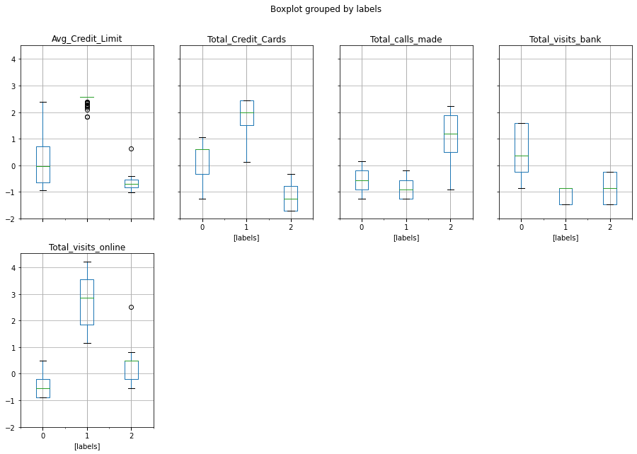

```python
#Boxplots to show hierarchical clustering by label (3 clusters) using complete link

ccdatascaled2.boxplot(by='labels', layout = (2,4),figsize=(15,10))
```

```python
# cophenet index is a measure of the correlation between the distance of points in feature space and distance on dendrogram
# closer it is to 1, the better is the clustering

Z_complete = linkage(ccdatascaled2, metric='euclidean', method='complete')
c_complete, coph_dists = cophenet(Z_complete , pdist(ccdatascaled2))

c_complete
```

```
0.9104796847785294
```

This is a really high cophenetic correlation coefficient. It suggests that this method is pretty good at clustering and that the dendogram stays faithful to pairwise distances in the data.

```python
#Summarize into a dataframe so that we can merge this information into a bigger dataframe for cophnetic coefficient comparison between models
Cophenetic_coeff_complete ={'Metric':['Cophenetic Coefficient'], 'Complete Linkage CC':[c_complete]}
dataframe12 = pd.DataFrame(Cophenetic_coeff_complete)
dataframe12
```

|  | Metric | Complete Linkage CC |
| --- | --- | --- |
| 0 | Cophenetic Coefficient | 0.91048 |

The cophenetic coefficient is also very high with the complete method for hierarchical clustering using Euclidean distance. We must now construct the tree dendogram.

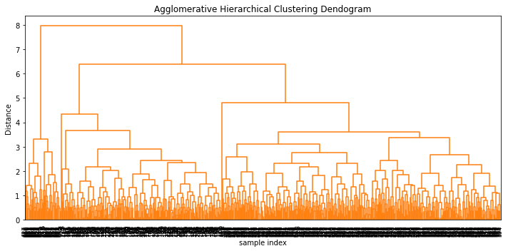

```python
plt.figure(figsize=(10, 5))
plt.title('Agglomerative Hierarchical Clustering Dendogram')
plt.xlabel('sample index')
plt.ylabel('Distance')
dendrogram(Z_complete, leaf_rotation=90.,color_threshold = 40, leaf_font_size=8. )
plt.tight_layout()
```

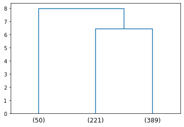

```python
#Let's narrow in on the last 3 merged clusters
dendrogram(
    Z_complete,
    truncate_mode='lastp',  # show only the last p merged clusters
    p=3,  # show only the last p merged clusters
)
plt.show()
```

```python
max_d = 6.3          #From reading the dendogram, we can see the dendogram distance at 3 clusters is about 6.3
```

```python
#Let's check to see if there are actually 3 cluster types.
from scipy.cluster.hierarchy import fcluster
clusters = fcluster(Z_complete, max_d, criterion='distance')
clusters
```

```
array([3, 2, 3, 3, 1, 2, 1, 2, 2, 2, 2, 2, 2, 2, 2, 2, 2, 2, 2, 2, 2, 2,
       2, 2, 2, 2, 2, 2, 2, 2, 2, 2, 2, 2, 2, 2, 2, 2, 2, 2, 2, 2, 3, 2,
       2, 2, 2, 2, 2, 2, 2, 2, 2, 2, 2, 2, 2, 2, 2, 2, 2, 2, 2, 2, 2, 2,
       2, 2, 2, 2, 2, 2, 2, 2, 2, 2, 2, 2, 2, 2, 2, 2, 2, 2, 2, 2, 2, 2,
       2, 2, 2, 2, 2, 2, 2, 2, 2, 2, 2, 2, 2, 2, 2, 2, 2, 2, 2, 2, 2, 2,
       2, 2, 2, 2, 2, 2, 2, 2, 2, 2, 2, 2, 2, 2, 2, 2, 2, 2, 2, 2, 2, 2,
       2, 2, 2, 2, 2, 2, 2, 2, 2, 2, 2, 2, 2, 2, 2, 2, 2, 2, 2, 2, 2, 2,
       2, 2, 2, 2, 2, 2, 2, 2, 2, 2, 2, 2, 2, 2, 2, 2, 2, 2, 2, 2, 2, 2,
       2, 2, 2, 2, 2, 2, 2, 2, 2, 2, 2, 2, 2, 2, 2, 2, 2, 2, 2, 2, 2, 2,
       2, 2, 2, 2, 2, 2, 2, 2, 2, 3, 2, 2, 2, 2, 2, 2, 2, 2, 2, 2, 2, 2,
       2, 2, 2, 2, 2, 2, 2, 2, 3, 3, 3, 3, 3, 3, 3, 3, 3, 3, 3, 3, 3, 3,
       3, 3, 3, 3, 3, 3, 3, 3, 3, 3, 3, 3, 3, 3, 3, 3, 3, 3, 3, 3, 3, 3,
       3, 3, 3, 3, 3, 3, 3, 3, 3, 3, 3, 3, 3, 3, 3, 3, 3, 3, 3, 3, 3, 3,
       3, 3, 3, 3, 3, 3, 3, 3, 3, 3, 3, 3, 3, 3, 3, 3, 3, 3, 3, 3, 3, 3,
       3, 3, 3, 3, 3, 3, 3, 3, 3, 3, 3, 3, 3, 3, 3, 3, 3, 3, 3, 3, 3, 3,
```

[output cut: 16 more lines]

```python
#Let's calculate the silhouette coefficient using the complete link hierarchical clustering method for 3 clusters

hc_3_clusters_silh_complete = silhouette_score(ccdatascaled2,clusters)
hc_3_clusters_silh_complete
```

```
0.5811328079630839
```

```python
#Make a dataframe with this information so that we can merge this into a big table and compare this measure to the others.

silhouette_score_hc_complete_3 ={'Metric':['Silhouette Score'], 'Complete(3 Clusters)':[hc_3_clusters_silh_complete]}
dataframe5 = pd.DataFrame(silhouette_score_hc_complete_3)
dataframe5
```

|  | Metric | Complete(3 Clusters) |
| --- | --- | --- |
| 0 | Silhouette Score | 0.581133 |

```python
#Let's look at the boxplots for 4 clusters using the complete linkage method.

model = AgglomerativeClustering(n_clusters=4, affinity='euclidean',  linkage='complete')
model.fit(ccdatascaled2)
```

```
AgglomerativeClustering(linkage='complete', n_clusters=4)
```

```python
#We can also append these as labels to the unscaled and scaled data (4 clusters).
ccdata2['labels'] = model.labels_
ccdatascaled2['labels'] = model.labels_
```

```
array([[<matplotlib.axes._subplots.AxesSubplot object at 0x000002AB38D6A340>,
      dtype=object)
```

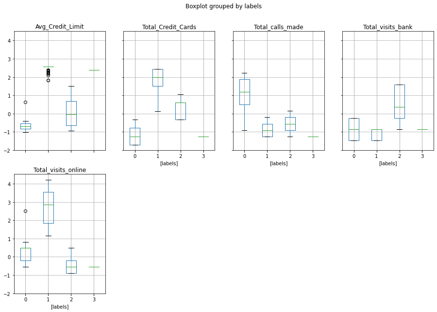

```python
#Boxplots to show hierarchical clustering by label (4 clusters) using complete link

ccdatascaled2.boxplot(by='labels', layout = (2,4),figsize=(15,10))
```

COMPLETE LINKAGE WITH 4 CLUSTERS

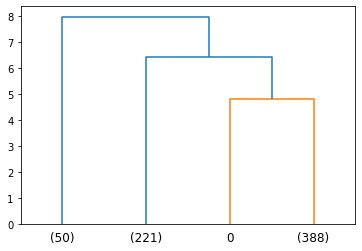

```python
#Calcuate the silhouette coefficient
#Let's narrow in on the last 4 merged clusters
dendrogram(
    Z_complete,
    truncate_mode='lastp',  # show only the last p merged clusters
    p=4,  # show only the last p merged clusters
)
plt.show()
```

```python
max_d = 4.7                 # Distance at which we see 4 clusters surface.
```

```python
#Let's check to see that there are 4 clusters present
from scipy.cluster.hierarchy import fcluster
clusters = fcluster(Z_complete, max_d, criterion='distance')
clusters
```

```
array([4, 2, 3, 3, 1, 2, 1, 2, 2, 2, 2, 2, 2, 2, 2, 2, 2, 2, 2, 2, 2, 2,
       2, 2, 2, 2, 2, 2, 2, 2, 2, 2, 2, 2, 2, 2, 2, 2, 2, 2, 2, 2, 3, 2,
       2, 2, 2, 2, 2, 2, 2, 2, 2, 2, 2, 2, 2, 2, 2, 2, 2, 2, 2, 2, 2, 2,
       2, 2, 2, 2, 2, 2, 2, 2, 2, 2, 2, 2, 2, 2, 2, 2, 2, 2, 2, 2, 2, 2,
       2, 2, 2, 2, 2, 2, 2, 2, 2, 2, 2, 2, 2, 2, 2, 2, 2, 2, 2, 2, 2, 2,
       2, 2, 2, 2, 2, 2, 2, 2, 2, 2, 2, 2, 2, 2, 2, 2, 2, 2, 2, 2, 2, 2,
       2, 2, 2, 2, 2, 2, 2, 2, 2, 2, 2, 2, 2, 2, 2, 2, 2, 2, 2, 2, 2, 2,
       2, 2, 2, 2, 2, 2, 2, 2, 2, 2, 2, 2, 2, 2, 2, 2, 2, 2, 2, 2, 2, 2,
       2, 2, 2, 2, 2, 2, 2, 2, 2, 2, 2, 2, 2, 2, 2, 2, 2, 2, 2, 2, 2, 2,
       2, 2, 2, 2, 2, 2, 2, 2, 2, 3, 2, 2, 2, 2, 2, 2, 2, 2, 2, 2, 2, 2,
       2, 2, 2, 2, 2, 2, 2, 2, 3, 3, 3, 3, 3, 3, 3, 3, 3, 3, 3, 3, 3, 3,
       3, 3, 3, 3, 3, 3, 3, 3, 3, 3, 3, 3, 3, 3, 3, 3, 3, 3, 3, 3, 3, 3,
       3, 3, 3, 3, 3, 3, 3, 3, 3, 3, 3, 3, 3, 3, 3, 3, 3, 3, 3, 3, 3, 3,
       3, 3, 3, 3, 3, 3, 3, 3, 3, 3, 3, 3, 3, 3, 3, 3, 3, 3, 3, 3, 3, 3,
       3, 3, 3, 3, 3, 3, 3, 3, 3, 3, 3, 3, 3, 3, 3, 3, 3, 3, 3, 3, 3, 3,
```

[output cut: 16 more lines]

```python
#Silhouette coefficient for 4 clusters using Complete Linkage
hc_4_clusters_silh_complete = silhouette_score(ccdatascaled2,clusters)
hc_4_clusters_silh_complete
```

```
0.5397253688116589
```

```python
#Make a dataframe with this information so that we can merge this into a big table and compare this measure to the others.

silhouette_score_hc_complete_4 ={'Metric':['Silhouette Score'], 'Complete(4 Clusters)':[hc_4_clusters_silh_complete]}
dataframe6 = pd.DataFrame(silhouette_score_hc_complete_4)
dataframe6
```

|  | Metric | Complete(4 Clusters) |
| --- | --- | --- |
| 0 | Silhouette Score | 0.539725 |

So far, 4 clusters yields a lower silhouette score compared to 3 clusters using complete linkage methods. It's the opposite for average linkage.

HIERARCHICAL CLUSTERING USING WARD LINKAGE METHOD

```python
# cophenet index is a measure of the correlation between the distance of points in feature space and distance on dendrogram
# closer it is to 1, the better is the clustering

Z_ward = linkage(ccdatascaled2, metric='euclidean', method='ward')
c_ward, coph_dists = cophenet(Z_ward , pdist(ccdatascaled2))

c_ward
```

```
0.8230379628614064
```

```python
#Summarize into a dataframe so that we can merge this information into a bigger dataframe for cophnetic coefficient comparison between models
Cophenetic_coeff_ward ={'Metric':['Cophenetic Coefficient'], 'Ward Linkage CC':[c_ward]}
dataframe13 = pd.DataFrame(Cophenetic_coeff_ward)
dataframe13
```

|  | Metric | Ward Linkage CC |
| --- | --- | --- |
| 0 | Cophenetic Coefficient | 0.823038 |

The cophenetic correlation coefficient is quite strong for Ward, but complete linkage dendogram is performing better. Let's now draw the ward dendogram.

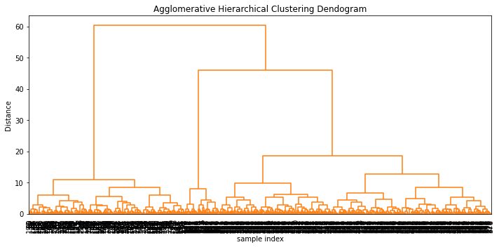

```python
plt.figure(figsize=(10, 5))
plt.title('Agglomerative Hierarchical Clustering Dendogram')
plt.xlabel('sample index')
plt.ylabel('Distance')
dendrogram(Z_ward, leaf_rotation=90.,color_threshold=600,  leaf_font_size=10. )
plt.tight_layout()
```

WARD METHOD 3 CLUSTERS

```python
#Let's look at the boxplots for 3 clusters using the ward linkage method.

model = AgglomerativeClustering(n_clusters=3, affinity='euclidean',  linkage='ward')
model.fit(ccdatascaled2)
```

```
AgglomerativeClustering(n_clusters=3)
```

```python
#We can also append these as labels to the unscaled and scaled data (3 clusters).
ccdata2['labels'] = model.labels_
ccdatascaled2['labels'] = model.labels_
```

```
array([[<matplotlib.axes._subplots.AxesSubplot object at 0x000002AB3903EB20>,
      dtype=object)
```

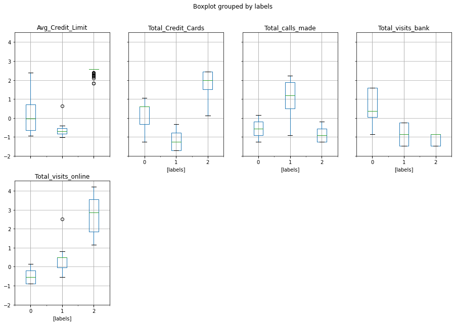

```python
#Boxplots to show hierarchical clustering by label (3 clusters) using ward link

ccdatascaled2.boxplot(by='labels', layout = (2,4),figsize=(15,10))
```

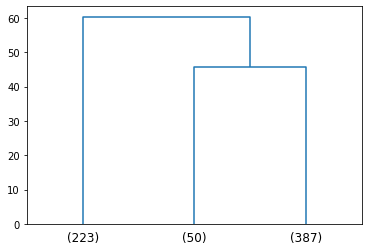

```python
#Let's narrow in on the last 3 merged clusters
dendrogram(
    Z_ward,
    truncate_mode='lastp',  # show only the last p merged clusters
    p=3,  # show only the last p merged clusters
)
plt.show()
```

```python
max_d = 45      #This is an approximate dendogram distance for 3 clusters.
```

```python
#Let's check for 3 clusters
from scipy.cluster.hierarchy import fcluster
clusters = fcluster(Z_ward, max_d, criterion='distance')
clusters
```

```
array([3, 1, 3, 3, 2, 1, 2, 1, 1, 1, 1, 1, 1, 1, 1, 1, 1, 1, 1, 1, 1, 1,
       1, 1, 1, 1, 1, 1, 1, 1, 1, 1, 1, 1, 1, 1, 1, 1, 1, 1, 1, 1, 1, 1,
       1, 1, 1, 1, 1, 1, 1, 1, 1, 1, 1, 1, 1, 1, 1, 1, 1, 1, 1, 1, 1, 1,
       1, 1, 1, 1, 1, 1, 1, 1, 1, 1, 1, 1, 1, 1, 1, 1, 1, 1, 1, 1, 1, 1,
       1, 1, 1, 1, 1, 1, 1, 1, 1, 1, 1, 1, 1, 1, 1, 1, 1, 1, 1, 1, 1, 1,
       1, 1, 1, 1, 1, 1, 1, 1, 1, 1, 1, 1, 1, 1, 1, 1, 1, 1, 1, 1, 1, 1,
       1, 1, 1, 1, 1, 1, 1, 1, 1, 1, 1, 1, 1, 1, 1, 1, 1, 1, 1, 1, 1, 1,
       1, 1, 1, 1, 1, 1, 1, 1, 1, 1, 1, 1, 1, 1, 1, 1, 1, 1, 1, 1, 1, 1,
       1, 1, 1, 1, 1, 1, 1, 1, 1, 1, 1, 1, 1, 1, 1, 1, 1, 1, 1, 1, 1, 1,
       1, 1, 1, 1, 1, 1, 1, 1, 1, 1, 1, 1, 1, 1, 1, 1, 1, 1, 1, 1, 1, 1,
       1, 1, 1, 1, 1, 1, 1, 1, 3, 3, 3, 3, 3, 3, 3, 3, 3, 3, 3, 3, 3, 3,
       3, 3, 3, 3, 3, 3, 3, 3, 3, 3, 3, 3, 3, 3, 3, 3, 3, 3, 3, 3, 3, 3,
       3, 3, 3, 3, 3, 3, 3, 3, 3, 3, 3, 3, 3, 3, 3, 3, 3, 3, 3, 3, 3, 3,
       3, 3, 3, 3, 3, 3, 3, 3, 3, 3, 3, 3, 3, 3, 3, 3, 3, 3, 3, 3, 3, 3,
       3, 3, 3, 3, 3, 3, 3, 3, 3, 3, 3, 3, 3, 3, 3, 3, 3, 3, 3, 3, 3, 3,
```

[output cut: 16 more lines]

```python
#Silhouette score for 3 cluster hierarchical clustering using ward linkage
hc_3_clusters_silh_ward = silhouette_score(ccdatascaled2,clusters)
hc_3_clusters_silh_ward
```

```
0.5322599958937628
```

```python
#Make a dataframe with this information so that we can merge this into a big table and compare this measure to the others.

silhouette_score_hc_ward_3 ={'Metric':['Silhouette Score'], 'Ward(3 Clusters)':[hc_3_clusters_silh_ward]}
dataframe7 = pd.DataFrame(silhouette_score_hc_ward_3)
dataframe7
```

|  | Metric | Ward(3 Clusters) |
| --- | --- | --- |
| 0 | Silhouette Score | 0.53226 |

This is considered a decent silhouette score.

HIERARCHICAL CLUSTERING USING WARD LINKAGE METHOD FOR 4 CLUSTERS

```python
#Let's look at the boxplots for 4 clusters using the ward linkage method.

model = AgglomerativeClustering(n_clusters=4, affinity='euclidean',  linkage='ward')
model.fit(ccdatascaled2)
```

```
AgglomerativeClustering(n_clusters=4)
```

```python
#We can also append these as labels to the unscaled and scaled data (4 clusters).
ccdata2['labels'] = model.labels_
ccdatascaled2['labels'] = model.labels_
```

```
array([[<matplotlib.axes._subplots.AxesSubplot object at 0x000002AB3A6A2A00>,
      dtype=object)
```

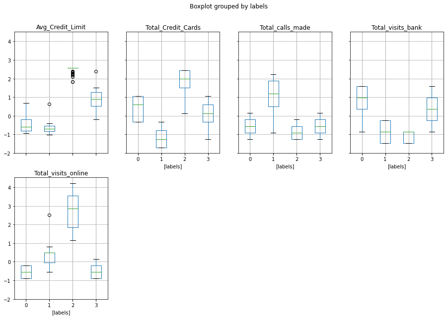

```python
#Boxplots to show hierarchical clustering by label (4 clusters) using ward link

ccdatascaled2.boxplot(by='labels', layout = (2,4),figsize=(15,10))
```

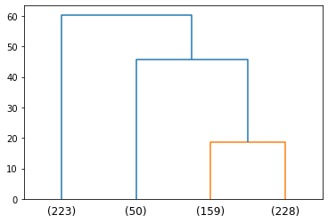

```python
#Let's narrow in on the last 4 merged clusters
dendrogram(
    Z_ward,
    truncate_mode='lastp',  # show only the last p merged clusters
    p=4,  # show only the last p merged clusters
)
plt.show()
```

```python
max_d = 18       #This is an approximate dendogram distance for 4 clusters using the ward method.
```

```python
from scipy.cluster.hierarchy import fcluster
clusters = fcluster(Z_ward, max_d, criterion='distance')
clusters
```

```
array([3, 1, 3, 4, 2, 1, 2, 1, 1, 1, 1, 1, 1, 1, 1, 1, 1, 1, 1, 1, 1, 1,
       1, 1, 1, 1, 1, 1, 1, 1, 1, 1, 1, 1, 1, 1, 1, 1, 1, 1, 1, 1, 1, 1,
       1, 1, 1, 1, 1, 1, 1, 1, 1, 1, 1, 1, 1, 1, 1, 1, 1, 1, 1, 1, 1, 1,
       1, 1, 1, 1, 1, 1, 1, 1, 1, 1, 1, 1, 1, 1, 1, 1, 1, 1, 1, 1, 1, 1,
       1, 1, 1, 1, 1, 1, 1, 1, 1, 1, 1, 1, 1, 1, 1, 1, 1, 1, 1, 1, 1, 1,
       1, 1, 1, 1, 1, 1, 1, 1, 1, 1, 1, 1, 1, 1, 1, 1, 1, 1, 1, 1, 1, 1,
       1, 1, 1, 1, 1, 1, 1, 1, 1, 1, 1, 1, 1, 1, 1, 1, 1, 1, 1, 1, 1, 1,
       1, 1, 1, 1, 1, 1, 1, 1, 1, 1, 1, 1, 1, 1, 1, 1, 1, 1, 1, 1, 1, 1,
       1, 1, 1, 1, 1, 1, 1, 1, 1, 1, 1, 1, 1, 1, 1, 1, 1, 1, 1, 1, 1, 1,
       1, 1, 1, 1, 1, 1, 1, 1, 1, 1, 1, 1, 1, 1, 1, 1, 1, 1, 1, 1, 1, 1,
       1, 1, 1, 1, 1, 1, 1, 1, 4, 4, 4, 4, 4, 4, 4, 4, 4, 4, 4, 4, 4, 4,
       4, 4, 4, 4, 4, 4, 4, 4, 4, 4, 4, 4, 4, 4, 4, 4, 4, 4, 4, 4, 4, 4,
       4, 4, 4, 4, 4, 4, 4, 4, 4, 4, 4, 4, 4, 4, 4, 4, 4, 4, 4, 4, 4, 4,
       4, 4, 4, 4, 4, 4, 4, 4, 4, 4, 4, 4, 4, 4, 4, 4, 4, 4, 4, 4, 4, 4,
       4, 4, 4, 4, 4, 4, 4, 4, 4, 4, 4, 4, 4, 4, 4, 4, 4, 4, 4, 4, 4, 4,
```

[output cut: 16 more lines]

```python
#Silhouette score for 4 clusters (ward linkage)
hc_4_clusters_silh_ward = silhouette_score(ccdatascaled2,clusters)
hc_4_clusters_silh_ward
```

```
0.5644569180404536
```

```python
#Make a dataframe with this information so that we can merge this into a big table and compare this measure to the others.

silhouette_score_hc_ward_4 ={'Metric':['Silhouette Score'], 'Ward(4 Clusters)':[hc_4_clusters_silh_ward]}
dataframe8 = pd.DataFrame(silhouette_score_hc_ward_4)
dataframe8
```

|  | Metric | Ward(4 Clusters) |
| --- | --- | --- |
| 0 | Silhouette Score | 0.564457 |

1. Compare K-means clusters with Hierarchical clusters. (5 marks)

COMPARING COPHENETIC COEFFICIENT OF EACH LINKAGE METHOD

```python
#Merging the cophenetic correlation coefficient dataframes for comparison.

Metrics_Dataframe2 = pd.merge(dataframe11,dataframe12,how='outer',on='Metric')
Metrics_Dataframe2 = pd.merge(Metrics_Dataframe2, dataframe13,how='outer',on='Metric')
Metrics_Dataframe2
```

|  | Metric | Average Linkage CC | Complete Linkage CC | Ward Linkage CC |
| --- | --- | --- | --- | --- |
| 0 | Cophenetic Coefficient | 0.893626 | 0.91048 | 0.823038 |

According to the results, complete linkage provides the highest cophenetic correlation (CPCC = 0.91). This means that of all the models we tested for hierarchical clustering, the dendogram created with complete linkage is the most faithful to the original Euclidean distances between scaled paired observations. This said, the dendogram created with complete linkage is perhaps the most reliable.

COMPARING SILHOUETTE SCORES FOR K MEANS

```python
# Merge K Means dataframes together for comparison of silhouette score comparison

Metrics_Dataframe1 = pd.merge(dataframe1,dataframe2,how='outer',on='Metric')
Metrics_Dataframe1
```

|  | Metric | K Means(3 Clusters) | K Means(4 Clusters) |
| --- | --- | --- | --- |
| 0 | Silhouette Score | 0.532248 | 0.521261 |

The higher and closer the silhouette score is to 1, the better it is normally. In this case, k = 3 has the higher silhouette score. Due to this, we would prefer to choose k =3 because we want a medium or a sweet spot between being too compressed (when everything is compressed into 1 cluster) and too accurate (when every point is its own cluster). The cost is not worth the benefit when it comes to increasing the amount of clusters beyond 3. The addition of a 4th cluster is not explaining much of the variation in the data.

COMPARING SILHOUETTE SCORES FOR HIERARCHICAL CLUSTERING

```python
# Merge all dataframes hierarchical clustering dataframes for silhouette score comparison

Metrics_Dataframe3 = pd.merge(dataframe3,dataframe4,how='outer',on='Metric')
Metrics_Dataframe3 = pd.merge(Metrics_Dataframe3, dataframe5,how='outer',on='Metric')
Metrics_Dataframe3 = pd.merge(Metrics_Dataframe3, dataframe6,how='outer',on='Metric')
Metrics_Dataframe3 = pd.merge(Metrics_Dataframe3, dataframe7,how='outer',on='Metric')
Metrics_Dataframe3 = pd.merge(Metrics_Dataframe3, dataframe8,how='outer',on='Metric')
Metrics_Dataframe3
```

|  | Metric | Average(3 Clusters) | Average(4 Clusters) | Complete(3 Clusters) | Complete(4 Clusters) | Ward(3 Clusters) | Ward(4 Clusters) |
| --- | --- | --- | --- | --- | --- | --- | --- |
| 0 | Silhouette Score | 0.43237 | 0.565811 | 0.581133 | 0.539725 | 0.53226 | 0.564457 |

These silhouette scores were calculated for these dendogram models. Normally, we cannot specify the number of clusters beforehand, and we must derive our conclusions about clusters from the visual dendogram itself.

From the above results, 3 clusters had better silhouette coefficients than 4 clusters in only complete linkage, while 4 clusters had better silhouette scores than 3 clusters in both average and ward linkage techniques.

Average linkage in general is influenced by outliers, or high and low numbers because it is reliant on the mean. Complete and ward linkages are robust methods that can handle the presence of outliers. It is important, therefore, to put more confidence in these 2 latter techniques due to their strength to withstand noise. Complete linkage for 3 clusters has a higher silhouette score (+0.04) and is closer to 1 than complete linkage for 4 clusters. (Also, complete linkage had the highest cophenetic correlation coefficient which implies that the dendogram is the most faithful to the Euclidian pairwise distances and is more likely the better dendogram. Please see above.). When it comes to Ward linkage, it can be argued that the addition of a 4th cluster does not add significant explanation in variation for the data and the cost is not worth the benefit.

If we were to compare K means methodology to hierarchical clustering, it would seem that K means would be better because it would lower the computational expense compared to hierarchical clustering. Building a K means model is faster than building a hierarchical model in Python. The big reason is attributed to the number of Euclidian distances that must be computed between observations; K means calculates 3n distances (in this case), while hierarchical dendograms calculates n(n+1)/2 distances. For this reason, hierarchical clusters have a lot of distances to calculate compared to K means. However, hierarchical clustering tends to generate more mathematically intuitive results and have less expected assumptions even if it takes more time to process.

In any case, all Silhouette coefficients are above 0, acknowledging that a decent amount of observations/objects are closer to the points within their own respective cluster than to the other neighboring clusters.

1. Analysis the clusters formed, tell us how is one cluster different from another and answer all the key questions. (10 marks)

Key Questions:

How many different segments of customers are there? How are these segments different from each other? What are your recommendations to the bank on how to better market to and service these customers?

The clusters are not entirely separated, so we cannot truly conclude that they are independent and separated from each other. However, we can still draw conclusions on the clusters formed from K means and Hierarchical Clustering. K Means and Hierarchical Clustering are both very different processes, so the clusters may yield very different cluster groupings.

To answer this question, we must look back at the unscaled dataset with the appended GROUPS/labels for 3 clusters

```python
#Means of every cluster for each feature using K Means clustering on unscaled data
ccdataclust.mean()
```

| GROUP | Avg_Credit_Limit | Total_Credit_Cards | Total_visits_bank | Total_visits_online | Total_calls_made |
| --- | --- | --- | --- | --- | --- |
| 0 | 33782.383420 | 5.515544 | 3.489637 | 0.981865 | 2.000000 |
| 1 | 12174.107143 | 2.410714 | 0.933036 | 3.553571 | 6.870536 |
| 2 | 102660.000000 | 8.740000 | 0.600000 | 10.900000 | 1.080000 |

```python
#Medians of every cluster for each feature using K Means clustering on unscaled data
ccdataclust.median()
```

| GROUP | Avg_Credit_Limit | Total_Credit_Cards | Total_visits_bank | Total_visits_online | Total_calls_made |
| --- | --- | --- | --- | --- | --- |
| 0 | 31000 | 6 | 3 | 1 | 2 |
| 1 | 12000 | 2 | 1 | 4 | 7 |
| 2 | 105000 | 9 | 1 | 11 | 1 |

Here I put the the tables for the means and medians of each feature grouped by cluster for K means

Group 1 may be the most financially liable of all the groups. They have on average the lowest average credit limit and own the least amount of credit cards. They tend to call the bank more often than use other methods of banking.

Group 2 seems to have very high average credit limits. They also are the group with the most credit cards. They give the impression that they are trustworthy, pay their bills on time which leads to higher average credit limit, and always get credit card offers. They also accept a lot of credit card offers. They don't visit the bank too often and don't call the bank often and instead, they access the bank's website instead.

I think it would be better if we had more information about the clientele, such as job type, age, and mortgage. These factors could perhaps improve segmentation.

Let's now look at the segmentation done by Hierarchical Clustering, using Complete Linkage (the best modeled dendogram from the analysis)

```python
#Means of every cluster for each feature using Hierarchical clustering (Complete Link) on unscaled data
ccdataclust5.mean()
```

| labels | Avg_Credit_Limit | Total_Credit_Cards | Total_visits_bank | Total_visits_online | Total_calls_made |
| --- | --- | --- | --- | --- | --- |
| 0 | 33629.820051 | 5.503856 | 3.478149 | 0.997429 | 2.015424 |
| 1 | 102660.000000 | 8.740000 | 0.600000 | 10.900000 | 1.080000 |
| 2 | 12149.321267 | 2.389140 | 0.918552 | 3.561086 | 6.909502 |

```python
#Medians of every cluster for each feature using Hierarchical clustering (Complete Link) on unscaled data
ccdataclust5.median()
```

| labels | Avg_Credit_Limit | Total_Credit_Cards | Total_visits_bank | Total_visits_online | Total_calls_made |
| --- | --- | --- | --- | --- | --- |
| 0 | 31000 | 6 | 3 | 1 | 2 |
| 1 | 105000 | 9 | 1 | 11 | 1 |
| 2 | 12000 | 2 | 1 | 4 | 7 |

The groups are labeled differently in hierarchical clustering but the patterns seen from k means is consistent. Group 0 from K means is also Group 0 here. Group 1 from K means is Group 2 here. Group 2 from K means is Group 1 here. Like what we saw in K means, the group with the highest average credit limit spend more time banking online. Those in the middle group spend more time calling the bank and paying visits to the bank. Calling the bank is also the preferred banking method for the group with higher liability.

Recommendations for the bank:

The target group: There seems to be 3 major segmentations among the customers in this banking dataset. Among these 3 clusters, the bank should focus on investing more money into reaching out to the middle tier of individuals. Those that are in the upper bracket have on average 9 credit cards already and may be less inclined to participate in another credit card promotion, despite having a high average credit limit across cards. It may be difficult to upsell to these individuals. This group is also very small in numbers. There are only approximately 50 individuals in this group. Those who belong to the lowest tier when it comes to average credit limit may be a financial liability because they have lower average credit limit, even though they may be more inclined to participate because they have less credit cards.

Advertisements suggestions: The bank should distribute advertisement funds across all 3 platforms but should put more emphasis on in-bank posters, phone commercial breaks while callers are on hold, and banking representatives promoting the deal by phone and in person. Online ads would only for the most part attract individuals of the extremes (the upper and lower tiers). The upper tier consists only a small portion of individuals and the lower tier could be a financial risk. Nonetheless, the payments for online ads should not be halted, as it could possibly attract other new customers with promising prospects.